# 개인프로젝트_kaggle_nlp_2

### kaggle_Natural Language Processing with Disaster Tweets

< 대회 설명 >

- 트위터는 비상시에 중요한 의사소통 채널이 되었지만, 사람들의 말이 정확한 비상사태를 예고하는지는 확실하지 않고, 참,거짓을 분별해낼 필요가 중요해졌다.

### 데이터 확인

```python
import numpy as np # linear algebra
import pandas as pd # data processing, CSV file I/O (e.g. pd.read_csv)
import os
import matplotlib.pyplot as plt
import seaborn as sns
from sklearn import feature_extraction, linear_model, model_selection, preprocessing
```

```python
df_train=pd.read_csv('C:/Users/User/Desktop/영우/개인프로젝트/kaggle_nlp/train.csv')
df_test=pd.read_csv('C:/Users/User/Desktop/영우/개인프로젝트/kaggle_nlp/test.csv')
df_submission=pd.read_csv('C:/Users/User/Desktop/영우/개인프로젝트/kaggle_nlp/sample_submission.csv')
```

```python
### 데이터 확인
```

```python
df_train
```

|  | id | keyword | location | text | target |
| --- | --- | --- | --- | --- | --- |
| 0 | 1 | NaN | NaN | Our Deeds are the Reason of this #earthquake M... | 1 |
| 1 | 4 | NaN | NaN | Forest fire near La Ronge Sask. Canada | 1 |
| 2 | 5 | NaN | NaN | All residents asked to 'shelter in place' are ... | 1 |
| 3 | 6 | NaN | NaN | 13,000 people receive #wildfires evacuation or... | 1 |
| 4 | 7 | NaN | NaN | Just got sent this photo from Ruby #Alaska as ... | 1 |
| ... | ... | ... | ... | ... | ... |
| 7608 | 10869 | NaN | NaN | Two giant cranes holding a bridge collapse int... | 1 |
| 7609 | 10870 | NaN | NaN | @aria_ahrary @TheTawniest The out of control w... | 1 |
| 7610 | 10871 | NaN | NaN | M1.94 [01:04 UTC]?5km S of Volcano Hawaii. htt... | 1 |
| 7611 | 10872 | NaN | NaN | Police investigating after an e-bike collided ... | 1 |
| 7612 | 10873 | NaN | NaN | The Latest: More Homes Razed by Northern Calif... | 1 |

7613 rows × 5 columns

```python
df_test
```

|  | id | keyword | location | text |
| --- | --- | --- | --- | --- |
| 0 | 0 | NaN | NaN | Just happened a terrible car crash |
| 1 | 2 | NaN | NaN | Heard about #earthquake is different cities, s... |
| 2 | 3 | NaN | NaN | there is a forest fire at spot pond, geese are... |
| 3 | 9 | NaN | NaN | Apocalypse lighting. #Spokane #wildfires |
| 4 | 11 | NaN | NaN | Typhoon Soudelor kills 28 in China and Taiwan |
| ... | ... | ... | ... | ... |
| 3258 | 10861 | NaN | NaN | EARTHQUAKE SAFETY LOS ANGELES ÛÒ SAFETY FASTE... |
| 3259 | 10865 | NaN | NaN | Storm in RI worse than last hurricane. My city... |
| 3260 | 10868 | NaN | NaN | Green Line derailment in Chicago http://t.co/U... |
| 3261 | 10874 | NaN | NaN | MEG issues Hazardous Weather Outlook (HWO) htt... |
| 3262 | 10875 | NaN | NaN | #CityofCalgary has activated its Municipal Eme... |

3263 rows × 4 columns

```python
df_submission
```

|  | id | target |
| --- | --- | --- |
| 0 | 0 | 0 |
| 1 | 2 | 0 |
| 2 | 3 | 0 |
| 3 | 9 | 0 |
| 4 | 11 | 0 |
| ... | ... | ... |
| 3258 | 10861 | 0 |
| 3259 | 10865 | 0 |
| 3260 | 10868 | 0 |
| 3261 | 10874 | 0 |
| 3262 | 10875 | 0 |

3263 rows × 2 columns

```python
df_train[df_train["target"]==0] #0=부정
```

|  | id | keyword | location | text | target |
| --- | --- | --- | --- | --- | --- |
| 15 | 23 | NaN | NaN | What's up man? | 0 |
| 16 | 24 | NaN | NaN | I love fruits | 0 |
| 17 | 25 | NaN | NaN | Summer is lovely | 0 |
| 18 | 26 | NaN | NaN | My car is so fast | 0 |
| 19 | 28 | NaN | NaN | What a goooooooaaaaaal!!!!!! | 0 |
| ... | ... | ... | ... | ... | ... |
| 7581 | 10833 | wrecked | Lincoln | @engineshed Great atmosphere at the British Li... | 0 |
| 7582 | 10834 | wrecked | NaN | Cramer: Iger's 3 words that wrecked Disney's s... | 0 |
| 7584 | 10837 | NaN | NaN | These boxes are ready to explode! Exploding Ki... | 0 |
| 7587 | 10841 | NaN | NaN | Sirens everywhere! | 0 |
| 7593 | 10848 | NaN | NaN | I just heard a really loud bang and everyone i... | 0 |

4342 rows × 5 columns

```python
df_train[df_train["target"]==1]
```

|  | id | keyword | location | text | target |
| --- | --- | --- | --- | --- | --- |
| 0 | 1 | NaN | NaN | Our Deeds are the Reason of this #earthquake M... | 1 |
| 1 | 4 | NaN | NaN | Forest fire near La Ronge Sask. Canada | 1 |
| 2 | 5 | NaN | NaN | All residents asked to 'shelter in place' are ... | 1 |
| 3 | 6 | NaN | NaN | 13,000 people receive #wildfires evacuation or... | 1 |
| 4 | 7 | NaN | NaN | Just got sent this photo from Ruby #Alaska as ... | 1 |
| ... | ... | ... | ... | ... | ... |
| 7608 | 10869 | NaN | NaN | Two giant cranes holding a bridge collapse int... | 1 |
| 7609 | 10870 | NaN | NaN | @aria_ahrary @TheTawniest The out of control w... | 1 |
| 7610 | 10871 | NaN | NaN | M1.94 [01:04 UTC]?5km S of Volcano Hawaii. htt... | 1 |
| 7611 | 10872 | NaN | NaN | Police investigating after an e-bike collided ... | 1 |
| 7612 | 10873 | NaN | NaN | The Latest: More Homes Razed by Northern Calif... | 1 |

3271 rows × 5 columns

- target이 0과 1의 label로 구성되어 있음
- 0 = 부정(제거해줘야 하는 쓸데없는 신고)
- 1 = 긍정

#### 데이터 개수 확인

```python
print("train data 개수 : {}".format(len(df_train)))
```

```
train data 개수 : 7613
```

```python
# 각 데이터 문자의 길이
# df_t 변수 생성
df_length = df_train["text"].apply(len)
df_length
```

```
0        69
1        38
2       133
3        65
4        88
       ...
7608     83
7609    125
7610     65
7611    137
7612     94
Name: text, Length: 7613, dtype: int64
```

#### 결측치 확인

```python
df_train.isnull().sum()
```

```
id             0
keyword       61
location    2533
text           0
target         0
dtype: int64
```

```python
df_test.isnull().sum()
```

```
id             0
keyword       26
location    1105
text           0
dtype: int64
```

#### 시각화

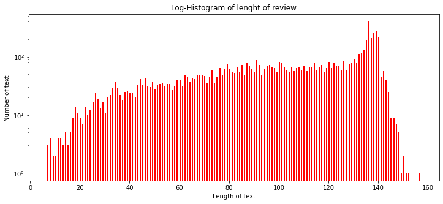

```python
# df_length 히스토그램
plt.figure(figsize=(12,5))
#히스토그램 선언
plt.hist(df_length, bins=300, alpha=1.0, color='r', label="word")
plt.yscale('log', nonposy='clip')
# 그래프 제목
plt.title('Log-Histogram of lenght of review')
# x축 라벨
plt.xlabel('Length of text')
# y축 라벨
plt.ylabel('Number of text ')
```

- 문자의 길이가 대부분 150이하
- 120~140에 분포가 가장 높음

```python
print('길이 최대값 : {}'.format(np.max(df_length)))
print('길이 최소값 : {}'.format(np.min(df_length)))
print('길이 평균값 : {}'.format(np.mean(df_length)))
print('길이 표준편차 : {}'.format(np.std(df_length)))
print('길이 중간값 : {}'.format(np.median(df_length)))
```

```
길이 최대값 : 157
길이 최소값 : 7
길이 평균값 : 101.03743596479706
길이 표준편차 : 33.779106292253026
길이 중간값 : 107.0
```

#### 이상치 확인

```
{'whiskers': [<matplotlib.lines.Line2D at 0x1efae1b3488>,
 'caps': [<matplotlib.lines.Line2D at 0x1efae1b3888>,
 'boxes': [<matplotlib.lines.Line2D at 0x1efae1ae7c8>],
 'medians': [<matplotlib.lines.Line2D at 0x1efae1b3388>],
 'fliers': [<matplotlib.lines.Line2D at 0x1efae18bb48>],
 'means': [<matplotlib.lines.Line2D at 0x1efae1b3408>]}
```

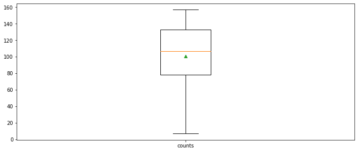

```python
# boxplot
plt.figure(figsize=(12,5))
# 첫 번째 인자 : 데이터 리스트 입력
# labels : 입력한 데이터에 대한 라벨
# showmeans : 평균값을 마크함

plt.boxplot(df_length,
           labels=['counts'],
           showmeans=True)
```

```python
#from wordcloud import WordCloud
```

```
(-0.5, 799.5, 599.5, -0.5)
```

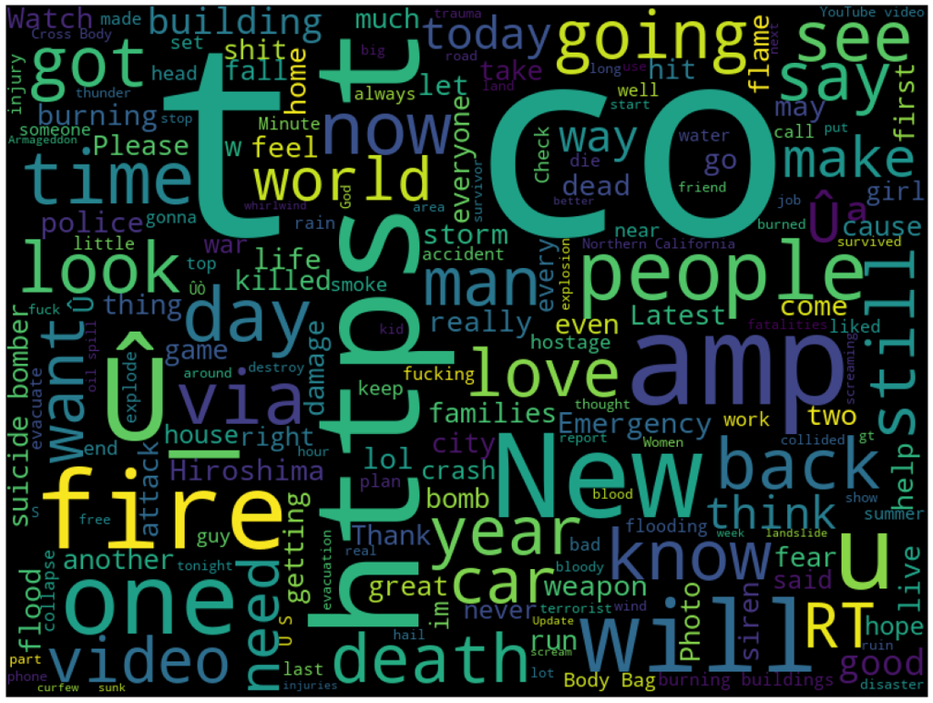

```python
# 가장 많이 사용된 text 알아보기 -> wordcloud 활용
# pip install wordcloud
from wordcloud import WordCloud
cloud = WordCloud(width=800, height=600).generate(" ".join(df_train['text']))
plt.figure(figsize=(20,15))
plt.imshow(cloud)
plt.axis('off')
```

- https가 가장 많이 사용된 단어 -> 데이터가 정제되지 않았음을 확인할 수 있음
- 전처리 작업에서 모두 삭제 필요

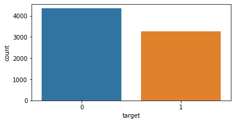

```python
# 각 라벨 분포 확인
fig, axe = plt.subplots(ncols=1) # subplot을 1개만 만들겠다.
fig.set_size_inches(6,3)
sns.countplot(df_train['target'])
```

```python
print("진짜 : {}".format(df_train['target'].value_counts()[1]))
print("가짜 : {}".format(df_train['target'].value_counts()[0]))
# 진짜보다 가짜 신고가 더 많음
# 가짜 신고가 더 많다는 것은 진짜 위급 상황일 때 시간을 지체시킬 수 있음
# 이를 잘 판별하여 위급 상황에서 잘 대처할 수 있도록 해야할 거 같음
```

```
진짜 : 3271
가짜 : 4342
```

```python
# 각 target당 단어의 개수 확인
word_cnt = df_train['text'].apply(lambda x :len(x.split(' ')))
```

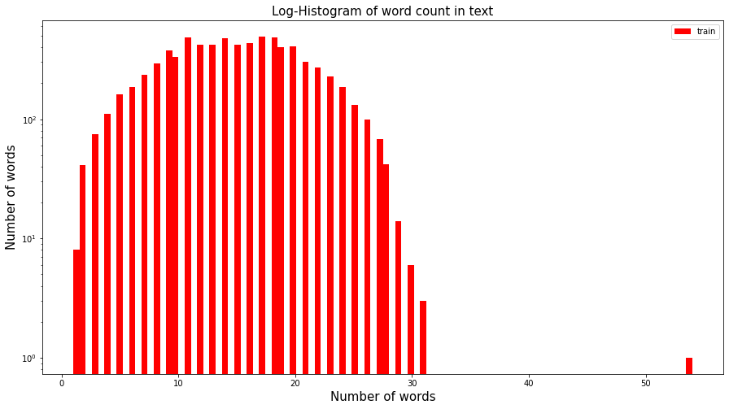

```python
plt.figure(figsize=(15,8))
plt.hist(word_cnt, bins=100, facecolor='r', label='train')
plt.title('Log-Histogram of word count in text', fontsize=15)
plt.yscale('log', nonposy='clip')
plt.legend()
plt.xlabel('Number of words', fontsize=15)
plt.ylabel('Number of words', fontsize=15)
```

```python
print('target 단어 개수 최대값 : {}'.format(np.max(word_cnt)))
print('target 단어 개수 최소값 : {}'.format(np.min(word_cnt)))
print('target 단어 개수 평균값 : {:.2f}'.format(np.mean(word_cnt)))
print('target 단어 개수 표준편차 : {:.2f}'.format(np.std(word_cnt))) #{:.2f} : 소수점 둘째자리까지 나타냄
print('target 단어 개수 중앙값 : {}'.format(np.median(word_cnt)))

print('target 제1사분위 : {}'.format(np.percentile(word_cnt,25)))
print('target 제3사분위 : {}'.format(np.percentile(word_cnt,75)))
```

```
target 단어 개수 최대값 : 54
target 단어 개수 최소값 : 1
target 단어 개수 평균값 : 14.93
target 단어 개수 표준편차 : 5.78
target 단어 개수 중앙값 : 15.0
target 제1사분위 : 11.0
target 제3사분위 : 19.0
```

- target의 3분위 값이 19개로 75%가 19개 이하의 단어를 가짐

### 데이터 전처리

- 영어 제외한 특수문자 등등 제거

```python
import re #데이터 정제
import pandas
import numpy #전처리 데이터 저장하기 위함
import json
from bs4 import BeautifulSoup #데이터 정제
from nltk.corpus import stopwords #불용어 제거
from tensorflow.python.keras.preprocessing.sequence import pad_sequences #텐서플로 전처리 모듈
from tensorflow.python.keras.preprocessing.text import Tokenizer #텐서플로 전처리 모듈
```

```python
print(df_train['text'][0])
```

```
Our Deeds are the Reason of this #earthquake May ALLAH Forgive us all
```

```python
print(df_train['text'][100])
```

```
.@NorwayMFA #Bahrain police had previously died in a road accident they were not killed by explosion https://t.co/gFJfgTodad
```

```python
import nltk
nltk.download('stopwords')
```

```
True
```

```python
text = df_train['text'][0]
text_t = re.sub("[^a-zA-Z]", " ", text) #영어 문자를 제외한 나머지를 모두 공백으로 변경해줌
```

```python
# 불용어 제거 -> 불용어 사전 이용
# 불용어 : 문장에서 자주 출현하지만 전체적인 의미에 영향을 주지 않는 단어, 조사, 관사 등 어휘
# 불용어가 포함되어 있으면 모델링을 할 때 노이즈를 주는 요인이 될 수 있음

#stop_words = set(stopwords.words('english')) # 불용어 set 만들기
#text_t = text_t.lower() #소문자 변환
#words=text_t.split() #단어 리스트 만들기
#words=[w for w in words if not w in stop_words] #불용어 제거한 리스트 만들기
```

```python
#문자열 합치기
#clean_text = ' '.join(words)
#print(clean_text)
```

```python
import string #string 에러 발생시 사용하면됨
```

```python
def cleanTweet(text):
    text = re.sub(r'@[A-Za-z0-9_]+','',text)
    text = re.sub(r'#','',text)
    text = re.sub(r'RT : ','',text)
    text = re.sub(r'\n','',text)
    #text = re.sub("[^a-zA-Z]", " ", text)
    # to remove emojis
    #text_t = re.sub(emoji.get_emoji_regexp(), r"", text)
    text = re.sub(r'https?:\/\/[A-Za-z0-9\.\/]+','',text)
    text = re.sub(r"https?://\S+|www\.\S+","",text)
    text = re.sub(r"<.*?>","",text)
    return text

def remove_punct(text):
    table=str.maketrans('','',string.punctuation) #string.punctuation-> 문자열에서 구두점 제거
    return text.translate(table)

def make_Lower(text): #대문자를 소문자로 변경
    return str.lower(text)
```

```python
print("before cleaning: ",df_train.text[200])
# apply(func, axis=0, raw...) pandas 객체에 열 or 행에 함수를 적용하게 해주는 메서드
print("after cleaning : ",df_train.text.apply(cleanTweet)[200])
print("after cleaning : ",df_train.text.apply(cleanTweet)[7610])
```

```
before cleaning:  HAPPENING NOW - HATZOLAH EMS AMBULANCE RESPONDING WITH DUAL SIRENS ANDÛ_ https://t.co/SeK6MQ6NJF
after cleaning :  HAPPENING NOW - HATZOLAH EMS AMBULANCE RESPONDING WITH DUAL SIRENS ANDÛ_
after cleaning :  M1.94 [01:04 UTC]?5km S of Volcano Hawaii.
```

```python
# train 셋에 적용 -> df_train에 적용안됨
df_train.text = df_train.text.apply(cleanTweet)
df_train.text = df_train.text.apply(remove_punct)
df_train.text =df_train.text.apply(make_Lower)

# test 셋에 적용 -> df_train에 적용안됨
df_test.text = df_test.text.apply(cleanTweet)
df_test.text = df_test.text.apply(remove_punct)
df_test.text = df_test.text.apply(make_Lower)
```

```python
#df_train[text] #적용이 안됐음
```

```python
# train 셋에 적용
clean_train = [] # 위에 코드는 적용이 안되어서 이 코드를 실행하고 한번 더 이 코드를 실행하면 df_train.text가 알맞게 바뀐 것을 확인할 수 있음
for text in df_train['text']:
    clean_train.append(cleanTweet(text))
    clean_train.append(remove_punct(text))
    clean_train.append(make_Lower(text))

# test 셋에 적용 -> test셋은 또 적용이 안됨...
clean_test = []
for text in df_test['text']:
    clean_test.append(cleanTweet(text))
    clean_test.append(remove_punct(text))
    clean_test.append(make_Lower(text))
```

```python
df_train.text # 잘 적용됨
```

```
0       our deeds are the reason of this earthquake ma...
1                   forest fire near la ronge sask canada
2       all residents asked to shelter in place are be...
3       13000 people receive wildfires evacuation orde...
4       just got sent this photo from ruby alaska as s...
                              ...
7608    two giant cranes holding a bridge collapse int...
7609      the out of control wild fires in california ...
7610                m194 0104 utc5km s of volcano hawaii
7611    police investigating after an ebike collided w...
7612    the latest more homes razed by northern califo...
Name: text, Length: 7613, dtype: object
```

```python
df_test.text #적용됨
```

```
0                      just happened a terrible car crash
1       heard about earthquake is different cities sta...
2       there is a forest fire at spot pond geese are ...
3                   apocalypse lighting spokane wildfires
4           typhoon soudelor kills 28 in china and taiwan
                              ...
3258    earthquake safety los angeles ûò safety faste...
3259    storm in ri worse than last hurricane my citya...
3260                    green line derailment in chicago
3261            meg issues hazardous weather outlook hwo
3262    cityofcalgary has activated its municipal emer...
Name: text, Length: 3263, dtype: object
```

```python
# 스펠링 전처리
# pip install pyspellchecker -> 에러떠서 cmd창에서 수행해줌
```

```python
#from spellchecker import SpellChecker
```

```python
# spell = SpellChecker()
def correct_spelling(text):
    corrected_text = []
    misspelled_words = spell.unknown(text.split())
    for word in text.split():
        if word in misspelled_words:
            corrected_text.append(spell.correction(word))
        else :
            corrected_text.append(word)
    return " ".join(corrected_text)

text = 'spelling mistake'
correct_spelling(text)
```

```
'spelling mistake'
```

```python
# train 셋에 적용 -> 프로그램이 안돌아감
#df_train[text] = df_train.text.apply(correct_spelling)
# test 셋에 적용
#df_test[text] = df_test.text.apply(correct_spelling)
```

- 불용어 처리

```python
#불용어 처리
from nltk.corpus import stopwords
# 불용어 가져오기
stop = set(stopwords.words('english'))
def remove_stopwords(text):
    # 불용어가 아닌 단어로 이루어진 새로운 리스트 생성
    text = [word.lower() for word in text.split() if word.lower() not in stop]
    return ' '.join(text)
```

```python
df_train[text] = df_train.text.apply(remove_stopwords)
#df_test[text] = df_test.text.apply(remove_stopwords)
```

```python
df_train[text]
```

```
0            deeds reason earthquake may allah forgive us
1                   forest fire near la ronge sask canada
2       residents asked shelter place notified officer...
3       13000 people receive wildfires evacuation orde...
4       got sent photo ruby alaska smoke wildfires pou...
                              ...
7608    two giant cranes holding bridge collapse nearb...
7609    control wild fires california even northern pa...
7610                      m194 0104 utc5km volcano hawaii
7611    police investigating ebike collided car little...
7612    latest homes razed northern california wildfir...
Name: cityofcalgary has activated its municipal emergency plan yycstorm, Length: 7613, dtype: object
```

```python
df_test[text] = df_test.text.apply(remove_stopwords)
```

```python
df_test[text]
```

```
0                             happened terrible car crash
1       heard earthquake different cities stay safe ev...
2       forest fire spot pond geese fleeing across str...
3                   apocalypse lighting spokane wildfires
4                  typhoon soudelor kills 28 china taiwan
                              ...
3258    earthquake safety los angeles ûò safety faste...
3259    storm ri worse last hurricane cityamp3others h...
3260                        green line derailment chicago
3261             meg issues hazardous weather outlook hwo
3262    cityofcalgary activated municipal emergency pl...
Name: cityofcalgary has activated its municipal emergency plan yycstorm, Length: 3263, dtype: object
```

- 벡터화시키기

```python
clean_train = pd.DataFrame({'text':df_train.text, 'target':df_train.target})
```

```python
clean_train
```

|  | text | target |
| --- | --- | --- |
| 0 | our deeds are the reason of this earthquake ma... | 1 |
| 1 | forest fire near la ronge sask canada | 1 |
| 2 | all residents asked to shelter in place are be... | 1 |
| 3 | 13000 people receive wildfires evacuation orde... | 1 |
| 4 | just got sent this photo from ruby alaska as s... | 1 |
| ... | ... | ... |
| 7608 | two giant cranes holding a bridge collapse int... | 1 |
| 7609 | the out of control wild fires in california ... | 1 |
| 7610 | m194 0104 utc5km s of volcano hawaii | 1 |
| 7611 | police investigating after an ebike collided w... | 1 |
| 7612 | the latest more homes razed by northern califo... | 1 |

7613 rows × 2 columns

- 인덱스로 구성된 벡터로 변환

```python
tokenizer = Tokenizer()
tokenizer.fit_on_texts(clean_train.text)
text_sequences = tokenizer.texts_to_sequences(clean_train.text)
```

```python
print(text_sequences[1])
```

```
[177, 42, 216, 672, 6561, 6562, 1340]
```

```python
word_vocab = tokenizer.word_index
word_vocab["<PAD>"]=0
print(word_vocab)
```

```
{'the': 1, 'a': 2, 'in': 3, 'to': 4, 'of': 5, 'and': 6, 'i': 7, 'is': 8, 'for': 9, 'on': 10, 'you': 11, 'my': 12, 'with': 13, 'it': 14, 'that': 15, 'at': 16, 'by': 17, 'this': 18, 'from': 19, 'are': 20, 'be': 21, 'was': 22, 'have': 23, 'like': 24, 'as': 25, 'up': 26, 'just': 27, 'so': 28, 'me': 29, …
```

```python
# 단어 개수 확인
print("전체 단어 개수:", len(word_vocab))
```

```
전체 단어 개수: 16102
```

```python
data_configs={}
data_configs['vocab']=word_vocab
data_configs['vocab_size']=len(word_vocab)
```

```python
# 각 데이터의 길이가 다르기 때문에 통일 시켜야 모델에 적용할 수 있다.
# 짧은 데이터는 0값으로 패딩처리

max_sequence_length = 107 #중간값으로 설정

train_inputs=pad_sequences(text_sequences, maxlen=max_sequence_length, padding='post')
print('Shape of train data:', train_inputs.shape)
```

```
Shape of train data: (7613, 107)
```

```python
# 정답을 나타내는 값을 넘파이 배열 형태로 저장
train_labels=np.array(df_train['target'])
print('Shape of label tensor:', train_labels.shape)
```

```
Shape of label tensor: (7613,)
```

```python
data_path = 'C:/Users/User/Desktop/영우/개인프로젝트/kaggle_nlp/'
train_input_data = 'train_input2.npy'
train_label_data = 'train_labels2.npy'
train_clean_data = 'train_clean2.csv'
data_configs='data_configs2.json'
```

```python
np.save(open(data_path+train_input_data, 'wb'), train_inputs)
np.save(open(data_path+train_label_data, 'wb'), train_labels)

# csv 형태로 저장
clean_train.to_csv(data_path+train_clean_data, index=False)

# json 형태 저장
json.dump(data_configs, open(data_path+data_configs, 'w'))
```

```python
clean_train.to_csv('C:/Users/User/Desktop/영우/개인프로젝트/kaggle_nlp/clean_train2')
```

- test 데이터 전처리

```python
df_test[text] # 앞에서 한번 전처리 진행해주었음 (불용어 제거까지 진행해주었음)
```

```
0                             happened terrible car crash
1       heard earthquake different cities stay safe ev...
2       forest fire spot pond geese fleeing across str...
3                   apocalypse lighting spokane wildfires
4                  typhoon soudelor kills 28 china taiwan
                              ...
3258    earthquake safety los angeles ûò safety faste...
3259    storm ri worse last hurricane cityamp3others h...
3260                        green line derailment chicago
3261             meg issues hazardous weather outlook hwo
3262    cityofcalgary activated municipal emergency pl...
Name: cityofcalgary has activated its municipal emergency plan yycstorm, Length: 3263, dtype: object
```

```python
clean_test = pd.DataFrame({'text':df_test.text, 'id':df_test.id})
test_id = np.array(df_test.id)
```

```python
text_sequences=tokenizer.texts_to_sequences(clean_test)
test_inputs = pad_sequences(text_sequences,maxlen=max_sequence_length, padding='post')
```

```python
np.save(open('C:/Users/User/Desktop/영우/개인프로젝트/kaggle_nlp/test_input2.npy', 'wb'), test_inputs)
np.save(open('C:/Users/User/Desktop/영우/개인프로젝트/kaggle_nlp/test_id2.npy', 'wb'), test_id)

# csv 형태로 저장
clean_test.to_csv('C:/Users/User/Desktop/영우/개인프로젝트/kaggle_nlp/test_clean2.csv')
```

### 모델링

#### 랜덤포레스트

```python
# countvectorizer를 활용한 벡터화
import pandas as pd
train_data = pd.read_csv('C:/Users/User/Desktop/영우/개인프로젝트/kaggle_nlp/clean_train2')
```

```python
texts = list(train_data['text'])
y = np.array(train_data['target'])
```

```python
from sklearn.feature_extraction.text import CountVectorizer
vectorizer = CountVectorizer(analyzer='word', max_features=5000) #최대길이=5000
train_data_features = vectorizer.fit_transform(texts)
```

```python
train_data_features
```

```
<7613x5000 sparse matrix of type '<class 'numpy.int64'>'
	with 82390 stored elements in Compressed Sparse Row format>
```

- 학습과 검정 데이터 분리

```python
from sklearn.model_selection import train_test_split
#Test_size = 0.2
#Random_seed = 42 -> random seed  type error 오류 -> random_state로 하면 오류 해결

train_input, eval_input, train_label, eval_label = train_test_split(train_data_features,
                                                                   y, test_size = 0.2, random_state =42)
```

- 모델 구현 학습

```python
from sklearn.ensemble import RandomForestClassifier

# 100개 의사결정 트리 사용
forest = RandomForestClassifier(n_estimators=100)
# 벡터화한 데이터와 정답 데이터 가지고 학습
forest.fit(train_input, train_label)
```

```
RandomForestClassifier()
```

- 성능평가

```python
print("Accuracy:%f" %forest.score(eval_input, eval_label)) # 처음보다 0.01% 오름
```

[output not shown]

```
Accuracy:0.785292
```

- 평가 데이터 불러오기

```python
test_data = pd.read_csv('C:/Users/User/Desktop/영우/개인프로젝트/kaggle_nlp/test_clean2.csv')
```

```python
# 유니코드 에러 해결방법
test_data['text']=test_data['text'].values.astype('U')
```

```python
test_texts = list(test_data['text'])
ids=list(test_data['id'])
```

```python
test_data_features = vectorizer.transform(test_texts)
```

```python
result = forest.predict(test_data_features)
output = pd.DataFrame(data={"id" : ids, "target":result})
output.to_csv('C:/Users/User/Desktop/영우/개인프로젝트/kaggle_nlp/submission_2.csv', index=False, quoting=3)
```

```python
print(result) #0.78 등수 조금 오름 (2000초반대)
```

```
[1 1 1 ... 1 1 0]
```

#### 딥러닝 모델 활용 - RNN(순환 신경망 분류 모델)

<순환신경망>

- 이전 정보가 점층적으로 쌓이면서 정보를 표현할 수 있는 모델
- 시간에 의존적, 순차적 데이터에 대한 문제에 활용됨
- 한 단어에 대한 정보를 입력하면 다음 단어를 맞추는 모델
- 현재정보 : 입력 상태(input state)/ 이전 정보 : 은닉상태(hidden state)
- 1) 랜덤 시드 고정 : 학습한 상황을 그대로 보존함

```python
import tensorflow as tf
seed_num = 1234
tf.random.set_seed(seed_num)
```

- 학습데이터 불러오기

```python
data_path = 'C:/Users/User/Desktop/영우/개인프로젝트/kaggle_nlp/'
train_input_data = 'train_input2.npy'
train_label_data = 'train_labels2.npy'
train_clean_data = 'train_clean2.csv'
data_configs='data_configs2.json'

train_input = np.load(open(data_path+train_input_data, 'rb'))
train_input = pad_sequences(train_input, maxlen=train_input.shape[1])
train_label = np.load(open(data_path+train_label_data, 'rb'))
prepro_configs = json.load(open(data_path+data_configs, 'r'))
# pad_sequences = 최대 길이를 설정해 모든 데이터에 대한 길이를 최대 길이에 맞추는 역할을 함
# 데이터 텍스트의 길이보다 길면 길이 제한, 길이보다 짧으면 패딩으로 토큰을 넣어줌
```

- 모델 하이퍼파라미터 정의

```python
import tensorflow as tf
from tensorflow import keras
```

```python
model_name = 'rnn_classifier_en'
BATCH_SIZE = 50
NUM_EPOCHS = 5
VALID_SPLIT = 0.1
MAX_LEN = train_input.shape[1]

kargs = {'model_name' : model_name,
        'vocab_size': 20000,
        'embedding_demension':32,
        'dropout_rate':0.2,
        'lstm_dimension':64,
        'dense_demension':10,
        'output_diemnsion':1}
```

- 모델구현

```python
class RNNClassifier(tf.keras.Model):
    def __init__(self, **kargs):
        super(RNNClassifier, self).__init__(name=kargs['model_name'])
        self.embedding=keras.layers.Embedding(input_dim=20000,
        output_dim=100)
        self.lstm_1_layer = tf.keras.layers.LSTM(kargs['lstm_dimension'],
                                                return_sequences=True)
        self.lstm_2_layer=tf.keras.layers.LSTM(kargs['lstm_dimension'])
        self.dropout = keras.layers.Dropout(kargs['dropout_rate'])
        self.fc1 = keras.layers.Dense(units=10,
                               activation=tf.keras.activations.tanh)
        self.fc2 = keras.layers.Dense(units=1,
                               activation=tf.keras.activations.sigmoid)

    def call(self,x):
        x = self.embedding(x)
        x = self.dropout(x)
        x = self.lstm_1_layer(x)
        x = self.lstm_2_layer(x)
        x = self.dropout(x)
        x = self.fc1(x)
        x = self.dropout(x)
        x = self.fc2(x)

        return x
```

- 모델 생성

```python
model = RNNClassifier(**kargs)
model.compile(optimizer=tf.keras.optimizers.Adam(1e-4),
             loss=tf.keras.losses.BinaryCrossentropy(),
             metrics=[tf.keras.metrics.BinaryAccuracy(name='accuracy')])
```

- 모델 학습

```python
import tensorflow as tf
print(tf.__version__)
```

```
2.5.0
```

```python
from keras.callbacks import EarlyStopping
from keras.callbacks import ModelCheckpoint
import gensim
from gensim import models
from gensim.models import Word2Vec
```

```python
earlystop_callback = EarlyStopping(monitor='val_caauracy', min_delta=0.0001, patience=2)

checkpoint_path = ('C:/Users/User/Desktop/영우/개인프로젝트/kaggle_nlp/train_model/weights.h5')
checkpoint_dir=os.path.dirname(checkpoint_path)

if os.path.exists(checkpoint_dir):
    print("{}--Folder already exists \n".format(checkpoint_dir))
else :
    os.makedirs(checkpoint_dir, exist_ok=True)
    print("{}--Folder create complete \n".format(checkpoint_dir))
```

```
C:/Users/User/Desktop/영우/개인프로젝트/kaggle_nlp/train_model--Folder create complete
```

```python
cp_callback = ModelCheckpoint(checkpoint_path, monitor='val_accuracy', verbose=1, save_best_only=True,
                             save_weights_only=True)
history = model.fit(train_input, train_label, batch_size=BATCH_SIZE, epochs=NUM_EPOCHS,
                   validation_split=VALID_SPLIT, callbacks=[earlystop_callback, cp_callback])
```

[output not shown]

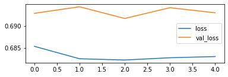

```python
plt.subplot(2,1,1)
plt.plot(history.history['loss'], label='loss')
plt.plot(history.history['val_loss'], label='val_loss')
plt.legend(loc='best')
```

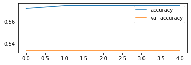

```python
plt.subplot(2,1,1)
plt.plot(history.history['accuracy'], label='accuracy')
plt.plot(history.history['val_accuracy'], label='val_accuracy')
plt.legend(loc='best')
```

- 심각하게 정확도가 안맞음

< 마무리 >

- nlp 분야에 대한 흥미가 생겨서 개별 프로젝트시간에 nlp를 다뤄보면 도움이 될 것 같아 선택했다.
- 배운점 : 자연어 처리가 그저 생소하기만 했었는데 프로젝트를 여러분야에 걸쳐 활용될 수 있음을 깨달았고, 프로젝트를 하면서 자연어 전처리 과정을 많이 공부할 수 있었고 전반적인 자연어처리 과정들을 익힐 수 있는 시간이었다.
- 부족한점 : 모델링 단계에서 특히 딥러닝 모델을 적용시키는 부분이 아직 많이 미숙하다. 이 부분은 딥러닝 모델링을 더 공부해야할 필요성을 느꼈으며 부족한 점을 개선시켜나가야겠다.